# Lab 1: Intro to R

Chris Moroney, Jordan Mielbrecht, Pauline Lee

2020-09-16

```r
library(tidyverse)
library(openintro)
```

### Exercise 1

```r
arbuthnot$girls
```

```
##  [1] 4683 4457 4102 4590 4839 4820 4928 4605 4457 4952 4784 5332 5200 4910 4617
## [16] 3997 3919 3395 3536 3181 2746 2722 2840 2908 2959 3179 3349 3382 3289 3013
## [31] 2781 3247 4107 4803 4881 5681 4858 4319 5322 5560 5829 5719 6061 6120 5822
## [46] 5738 5717 5847 6203 6033 6041 6299 6533 6744 7158 7127 7246 7119 7214 7101
## [61] 7167 7302 7392 7316 7483 6647 6713 7229 7767 7626 7452 7061 7514 7656 7683
## [76] 5738 7779 7417 7687 7623 7380 7288
```

### Exercise 2

In the arbuthnot data set, there does seem to be an apparent trend in the data for girls baptized overtime. In general, as time progresses by year, the number of girls baptized appears to increase. Although between 1640 and 1660 the number of girls baptized decreases significantly, the rest of the data shows that the data generally increases over time.

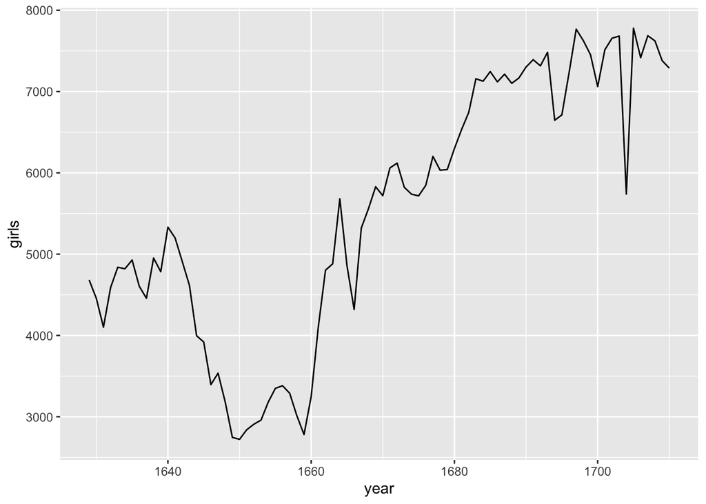

```r
# plots the "girls" variable against the year as a line graph
ggplot(data = arbuthnot, aes(x = year, y = girls)) +
  geom_line()
```

### Exercise 3

The line graph produced from the newly created “boy_prop” variable shows a consistent trend of data with little variance. Although the pattern of the graph shows many spikes, all of the data is very close to 0.52, which shows there is very little variance in the data for every year. This means that for every year in the data set, the proportion of boys baptized compared to the total population is most likely between 0.51 and 0.53.

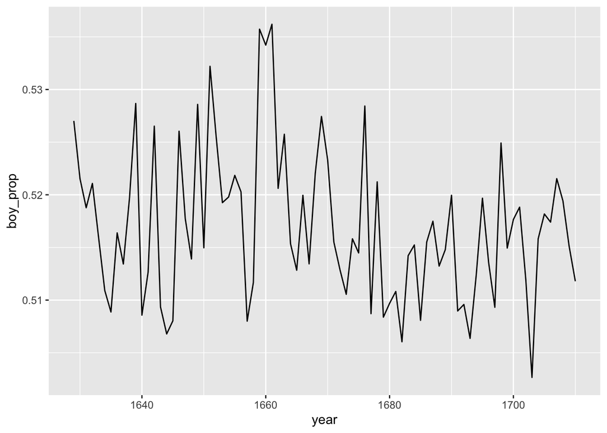

```r
# Calculates total baptisms and adds variable to the dat aset
arbuthnot <- arbuthnot %>%
  mutate(total = boys + girls)
# Calculates proportion of boys baptized compared to the population, then adds to the data set
arbuthnot <- arbuthnot %>%
  mutate(boy_prop = boys / total)
# plots boy_prop
ggplot(data = arbuthnot, aes(x = year, y = boy_prop)) +
  geom_line()
```

### Exercise 4

In the data set, “present”, we see that the years included to this data set is every year from 1940 to 2002. We were able to see this by using the command present$year, which shows all of the entries in the years column. The dimensions of the data set is 63 rows and 3 columns, and we were able to figure this out by using the command glimpse(present). The variable common names are “year”, “boys”, and “girls” which also come from the glimpse(present) command.

```r
# Shows the dimensions of the data set and all variable names
glimpse(present)
```

```
## Rows: 63
## Columns: 3
## $ year  <dbl> 1940, 1941, 1942, 1943, 1944, 1945, 1946, 1947, 1948, 1949, 195…
## $ boys  <dbl> 1211684, 1289734, 1444365, 1508959, 1435301, 1404587, 1691220, …
## $ girls <dbl> 1148715, 1223693, 1364631, 1427901, 1359499, 1330869, 1597452, …
```

```r
# Shows all of the years in the data set
present$year
```

```
##  [1] 1940 1941 1942 1943 1944 1945 1946 1947 1948 1949 1950 1951 1952 1953 1954
## [16] 1955 1956 1957 1958 1959 1960 1961 1962 1963 1964 1965 1966 1967 1968 1969
## [31] 1970 1971 1972 1973 1974 1975 1976 1977 1978 1979 1980 1981 1982 1983 1984
## [46] 1985 1986 1987 1988 1989 1990 1991 1992 1993 1994 1995 1996 1997 1998 1999
## [61] 2000 2001 2002
```

### Exercise 5

The counts of the present data set differ from the Arbuthnot data set in that the counts in the present data set contain counts for boys and girls that are substantially larger than that of the Arbuthnot data set. On top of this, the two data sets contain a different time period, in which Arbuthnot takes place between year 1629 and 1710, while present takes place between year 1940 and 2002.

```r
# Shows a preview of the arbuthnot data set
glimpse(arbuthnot)
```

```
## Rows: 82
## Columns: 5
## $ year     <int> 1629, 1630, 1631, 1632, 1633, 1634, 1635, 1636, 1637, 1638, …
## $ boys     <int> 5218, 4858, 4422, 4994, 5158, 5035, 5106, 4917, 4703, 5359, …
## $ girls    <int> 4683, 4457, 4102, 4590, 4839, 4820, 4928, 4605, 4457, 4952, …
## $ total    <int> 9901, 9315, 8524, 9584, 9997, 9855, 10034, 9522, 9160, 10311…
## $ boy_prop <dbl> 0.5270175, 0.5215244, 0.5187705, 0.5210768, 0.5159548, 0.510…
```

```r
# Shows a preview of the present data set
glimpse(present)
```

```
## Rows: 63
## Columns: 3
## $ year  <dbl> 1940, 1941, 1942, 1943, 1944, 1945, 1946, 1947, 1948, 1949, 195…
## $ boys  <dbl> 1211684, 1289734, 1444365, 1508959, 1435301, 1404587, 1691220, …
## $ girls <dbl> 1148715, 1223693, 1364631, 1427901, 1359499, 1330869, 1597452, …
```

### Exercise 6

We can see that in a plot of boys born over time in the present data set, the proportion of boys born decreases slightly over time. There is an apparent downwards trend starting from 1940 to 1960, and then again after 1980 to 2000. Despite a small trend increase between 1960 to 1980, the general shape of the graph shows a decrease in births for boys proportionate to girls. This tells us that Arbuthnot’s observation of boys being born in greater proportion over time does not hold up in the U.S. because the downward trend found in the graph shows boys decreasing in proportion over time.

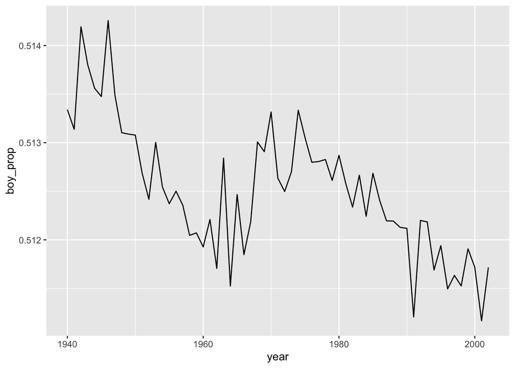

```r
# Calculates total births between boys and girls and adds variable to the data set
present <- present %>%
  mutate(total = boys + girls)
# Calculates proportion of boys baptized compared to the population, then adds to the data set
present <- present %>%
  mutate(boy_prop = boys / total)
# plots boy_prop
ggplot(data = present, aes(x = year, y = boy_prop)) +
  geom_line()
```

### Exercise 7

In the present data set, we see that between 1940 and 2002, the year of 1961 contains the most births in the U.S.

```r
present <- present %>%
  mutate(total = boys + girls)
present %>%
  arrange(desc(total))
```

```
## # A tibble: 63 x 5
##     year    boys   girls   total boy_prop
##    <dbl>   <dbl>   <dbl>   <dbl>    <dbl>
##  1  1961 2186274 2082052 4268326    0.512
##  2  1960 2179708 2078142 4257850    0.512
##  3  1957 2179960 2074824 4254784    0.512
##  4  1959 2173638 2071158 4244796    0.512
##  5  1958 2152546 2051266 4203812    0.512
##  6  1962 2132466 2034896 4167362    0.512
##  7  1956 2133588 2029502 4163090    0.513
##  8  1990 2129495 2028717 4158212    0.512
##  9  1991 2101518 2009389 4110907    0.511
## 10  1963 2101632 1996388 4098020    0.513
## # … with 53 more rows
```